# re2r Benchmark

2016-08-21

- TRE - TRE in R base
- PRCE - Perl Compatible Regular Expressions in R base
- ICU - ICU with stringi
- RE2n - RE2 with string pattern
- RE2c - RE2 with pre-compiled regular expression

## ReDos

The regular expression denial of service (ReDoS) is an algorithmic complexity attack that produces a denial-of-service by providing a regular expression that takes a very long time to evaluate.

### StackOverflow.com Outage - July 20, 2016

The [blog post](http://stackstatus.net/post/147710624694/outage-postmortem-july-20-2016) explained the direct cause of the outage. An regular expressions, which is used to trim unicode space from start and end of a line, consume high CPU on the web servers.

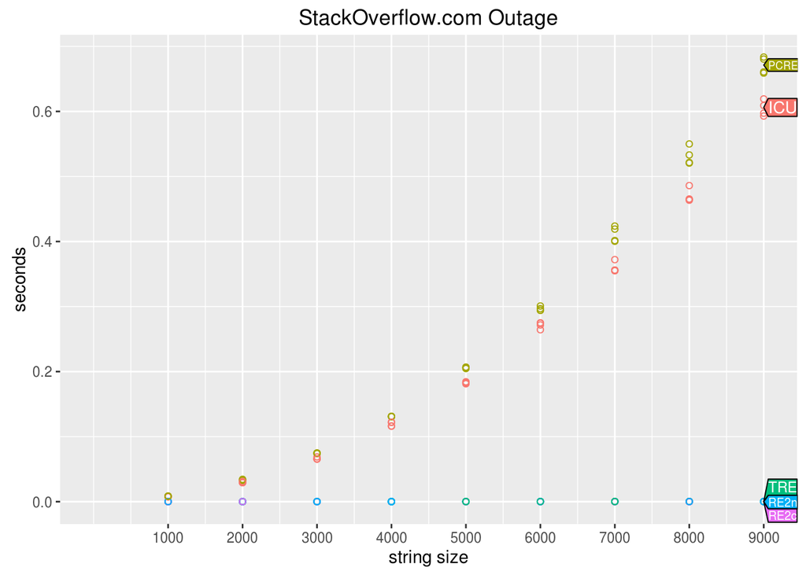

```r
pattern = enc2utf8("^[\\s\u200c]+|[\\s\u200c]+$")

times.list <- list()
index = 1
seq_ = seq(1000,9000,by = 1000)
for(N in seq_){
    # string and pattern
    string = paste0("-- play happy sound for player to enjoy. ", paste0(rep(" ",N), collapse = ""),"boom!")

    # pre-compiled RE2
    regexp = re2(pattern)

    # run gc
    invisible(gc())

    # benchmark
    N.times <- microbenchmark(
        ICU = stri_detect_regex(string, pattern = pattern),
        PCRE = grepl(pattern, string, perl = TRUE),
        TRE = grepl(pattern, string, perl = FALSE),
        RE2n = re2_detect(string, pattern),
        RE2c = re2_detect(string, regexp),
        times = 4)

    times.list[[index]] <- data.frame(N, N.times)
    index= index+1
}

times <- do.call(rbind, times.list)

direct.label(linear.legend(times, limit=c(0,9000), breaks = seq_,xlab_name = "string size", title = "StackOverflow.com Outage"), "last.polygons")
```

### Java Classname

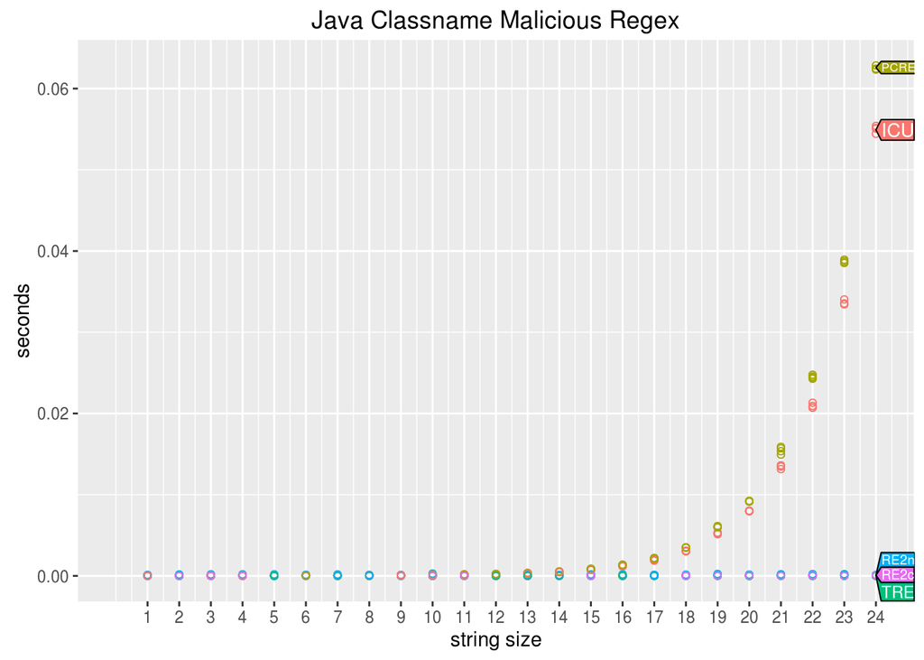

```r
pattern = "^(([a-z])+.)+[A-Z]([a-z])+$"

times.list <- list()
index = 1
seq_ = seq(1,24,by = 1)
for(N in seq_){
    # string and pattern
    string = paste0(paste0(rep("a",N), collapse = ""),"boom!")

    # pre-compiled RE2
    regexp = re2(pattern)

    # run gc
    invisible(gc())

    # benchmark
    N.times <- microbenchmark(
        ICU = stri_detect_regex(string, pattern = pattern),
        PCRE = grepl(pattern, string, perl = TRUE),
        TRE = grepl(pattern, string, perl = FALSE),
        RE2n = re2_detect(string, pattern),
        RE2c = re2_detect(string, regexp),
        times = 4)

    times.list[[index]] <- data.frame(N, N.times)
    index= index+1
}

times <- do.call(rbind, times.list)

direct.label(linear.legend(times, limit=c(0,24), breaks = seq_,xlab_name = "string size", title = "Java Classname Malicious Regex"), "last.polygons")
```

### “a?a”

Derived from Toby Dylan Hocking tdhock/regex-tutorial

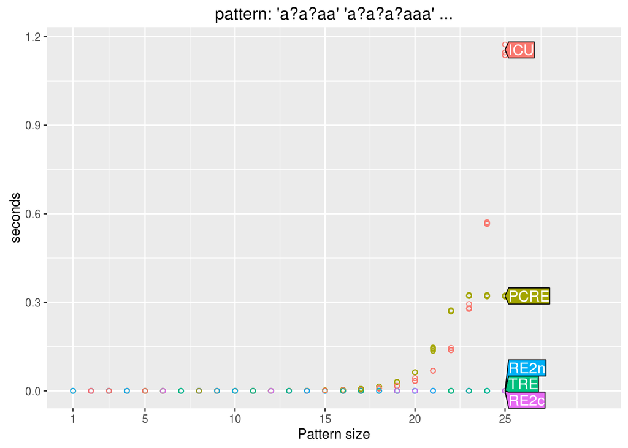

```r
times.list <- list()

for(N in c(1:25)){
    # string and pattern
    string <- paste(rep("a", N), collapse="")
    pattern <- paste(rep(c("a?", "a"), each=N), collapse="")

    # pre-compiled RE2
    regexp = re2(pattern)

    # run gc
    invisible(gc())

    # benchmark
    N.times <- microbenchmark(
        ICU = stri_detect_regex(string, pattern = pattern),
        PCRE = grepl(pattern, string, perl = TRUE),
        TRE = grepl(pattern, string, perl = FALSE),
        RE2n = re2_detect(string, pattern),
        RE2c = re2_detect(string, regexp),
        times = 5)

    times.list[[N]] <- data.frame(N, N.times)
}

times <- do.call(rbind, times.list)

direct.label(linear.legend(times, xlab_name = "Pattern size", title = "pattern: 'a?a?aa' 'a?a?a?aaa' ..."), "last.polygons")
```

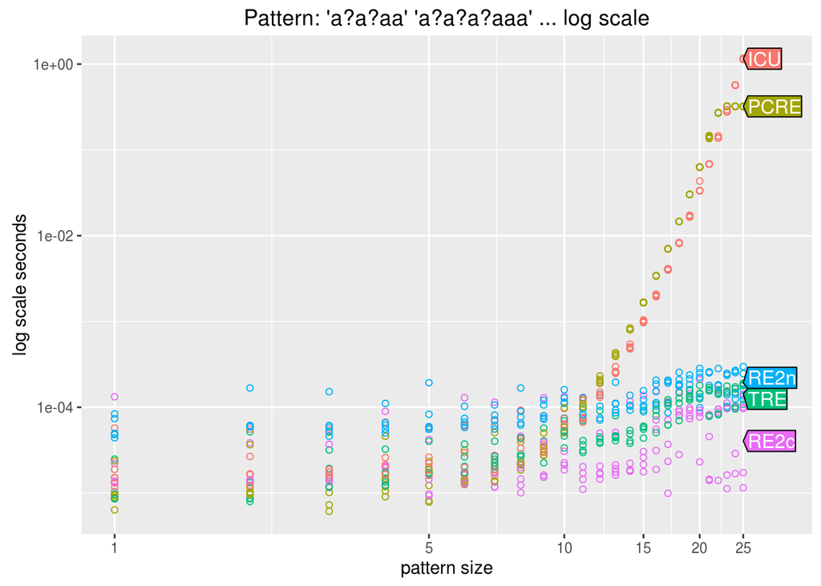

```r
direct.label(log.legend(times, xlab_name = "pattern size", title = "Pattern: 'a?a?aa' 'a?a?a?aaa' ... log scale"), "last.polygons")
```

```r
string <- paste(rep("a", 27), collapse="")
pattern <- paste(rep(c("a?", "a"), each=27), collapse="")

system.time(re2_detect(string,pattern))
```

```
#>    user  system elapsed
#>       0       0       0
```

```r
system.time(stri_detect_regex(string,pattern))
```

```
#>    user  system elapsed
#>    4.74    0.00    4.74
```

## Fail to Match

These strings will fail to match the pattern, and they test the speed of failed match.

```r
gen_bench = function(range_, pattern) {
    times.list <- list()
    index = 1
    for (N in range_) {
        # pre-compiled RE2
        regexp = re2(pattern)
        string = stringi::stri_rand_strings(1, N,
                                            pattern = "[a-zA-Z0-9 !@#$%()*Ω≈ç√∫˜µåœ∑†¨ˆ˙©ƒ]")

        # run gc
        invisible(gc())

        # benchmark
        N.times <- microbenchmark(
            ICU = stri_detect_regex(string, pattern = pattern),
            PCRE = grepl(pattern, string, perl = TRUE),
            TRE = grepl(pattern, string, perl = FALSE),
            RE2n = re2_detect(string, pattern),
            RE2c = re2_detect(string, regexp),
            times = 5
        )

        times.list[[index]] <- data.frame(N, N.times)
        index = index + 1
    }

    times <- do.call(rbind, times.list)
    return(times)
}

plot_bench = function(pattern) {
    res = gen_bench(seq(from = 10000, to = 70000, by = 10000), pattern)

    direct.label(
        linear.legend(
            res,
            limit = c(0, 71000),
            breaks = seq(from = 10000, to = 70000, by = 10000),
            xlab_name = "string size"
        ),
        "last.polygons"
    )
}
```

These two are easy because they start with an A, giving the search loop in something to call `memchr` in C++. These tests are from RE2 library.

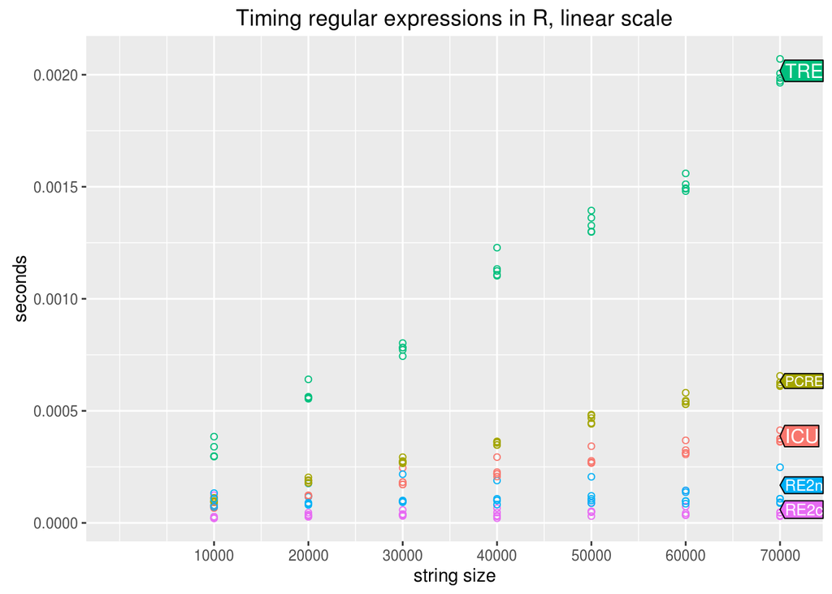

```r
EASY0 = "ABCDEFGHIJKLMNOPQRSTUVWXYZ$"
plot_bench(EASY0)
```

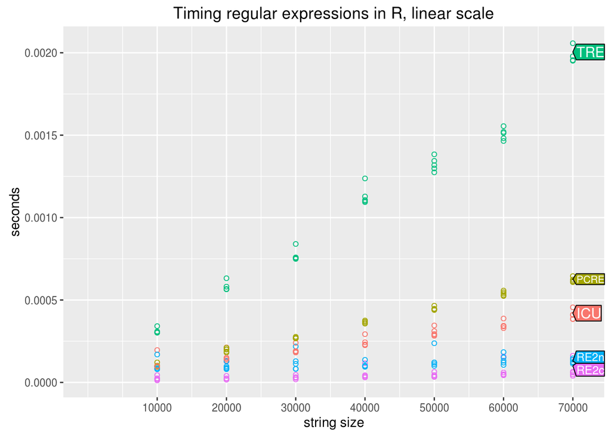

```r
EASY1 = "A[AB]B[BC]C[CD]D[DE]E[EF]F[FG]G[GH]H[HI]I[IJ]J$"
plot_bench(EASY1)
```

This is a little harder, since it starts with a character class and thus can’t be `memchr`’ed in C++.

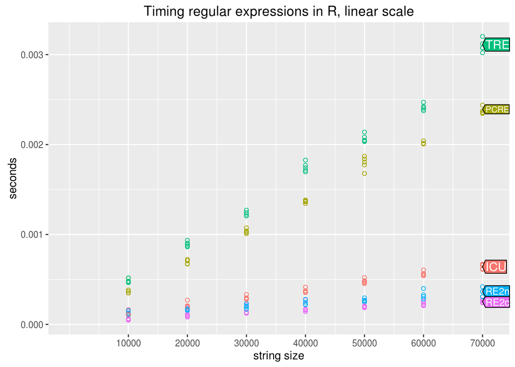

```r
MEDIUM = "[XYZ]ABCDEFGHIJKLMNOPQRSTUVWXYZ$"
plot_bench(MEDIUM)
```

This is a fair amount harder, because of the leading [ -~]*. A bad backtracking implementation will take O(text^2) time to figure out there’s no match.

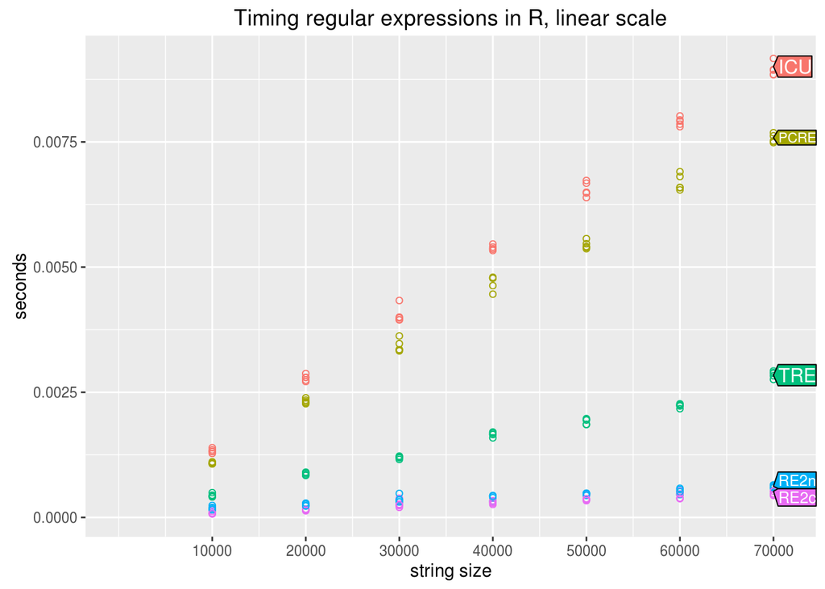

```r
HARD = "[ -~]*ABCDEFGHIJKLMNOPQRSTUVWXYZ$"
plot_bench(HARD)
```

This stresses engines that are trying to track parentheses.

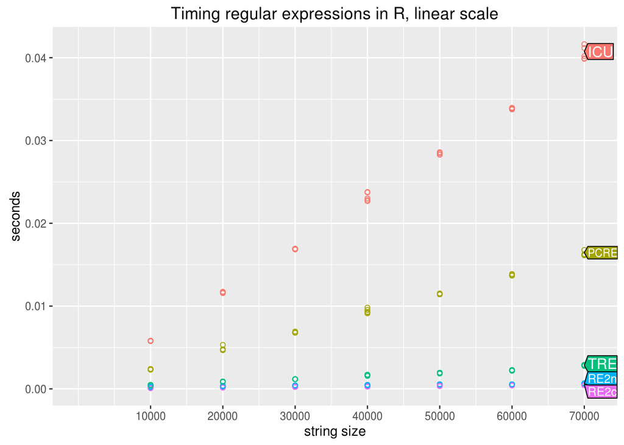

```r
PARENS = "([ -~])*(A)(B)(C)(D)(E)(F)(G)(H)(I)(J)(K)(L)(M)(N)(O)(P)(Q)(R)(S)(T)(U)(V)(W)(X)(Y)(Z)$"
plot_bench(PARENS)
```

This pattern has a high degree of fanout. NFA execution will be particularly slow.

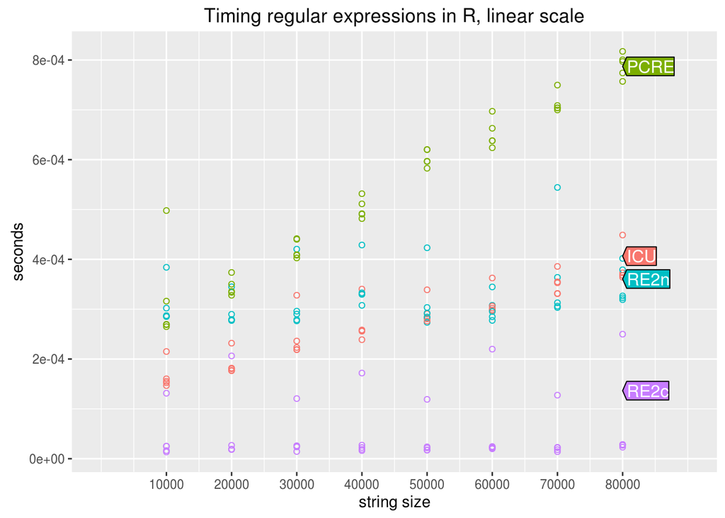

```r
FANOUT = "(?:[\\x{80}-\\x{10FFFF}]?){100}[\\x{80}-\\x{10FFFF}]"
range_ = seq(from = 10000, to = 80000, by = 10000)
times.list <- list()
index = 1
for(N in range_){
    # pre-compiled RE2
    regexp = re2(FANOUT)
    pattern = FANOUT
    string = stringi::stri_rand_strings(1,N,
                                        pattern="[a-zA-Z0-9 !@#$%()*Ω≈ç√∫˜µåœ∑†¨ˆ˙©ƒ]")

    # run gc
    invisible(gc())

    # benchmark
    N.times <- microbenchmark(
        ICU = stri_detect_regex(string, pattern = pattern),
        PCRE = grepl(pattern, string, perl = TRUE),
        RE2n = re2_detect(string, pattern),
        RE2c = re2_detect(string, regexp),
        times = 5)

    times.list[[index]] <- data.frame(N, N.times)
    index = index+1
}

times <- do.call(rbind, times.list)

direct.label(linear.legend(times, limit = c(0,90000), breaks = range_, xlab_name = "string size"), "last.polygons")
```

## stringi benchmark

Benchmarks from the [stringi](https://github.com/Rexamine/stringi/blob/master/devel/benchmarks) package.

### CRAN logs

Detect a fixed pattern in ASCII text (144k strings).

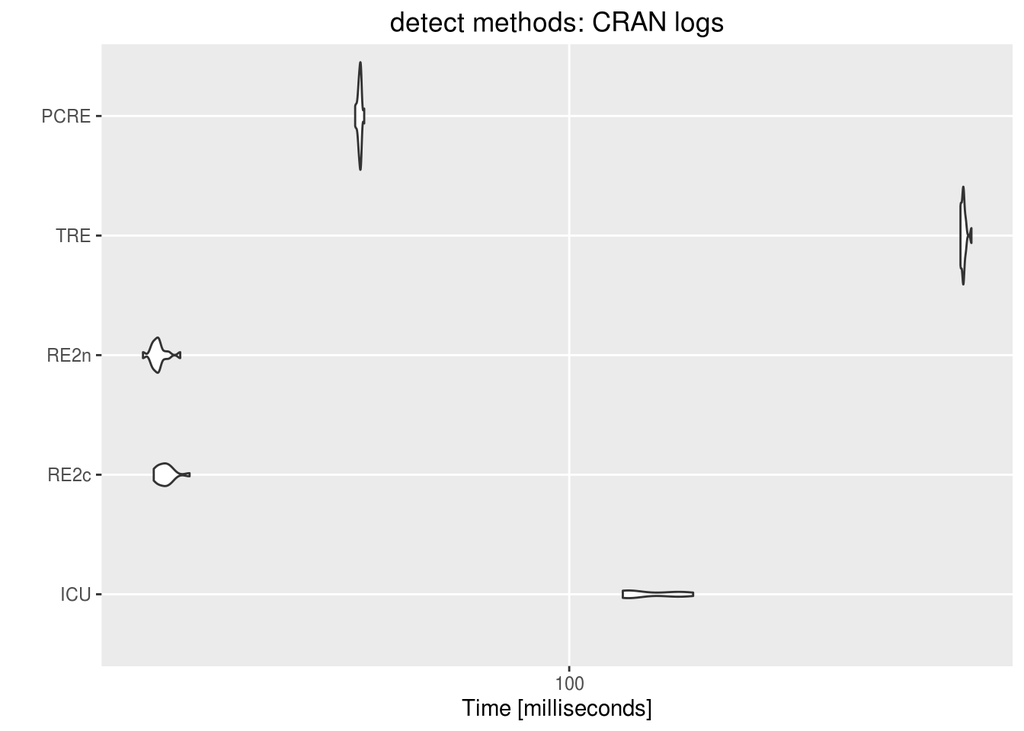

```r
if (!file.exists('./test1.csv.gz')) {
    # don't change the URL!
    download.file('http://cran-logs.rstudio.com/2014/2014-03-18.csv.gz',
                  './test1.csv.gz')
}

f <- gzfile('./test1.csv.gz')
data <- enc2native(readLines(f, encoding="ASCII"))
close(f)
regexp = re2(',\\"stringi\\",')
invisible(gc(reset=TRUE))
res = microbenchmark(
    ICU = stri_detect_regex(data, ',\\"stringi\\",'),
    RE2c = re2_detect(data, ',\\"stringi\\",'),
    RE2n = re2_detect(data, regexp),
    TRE = grepl(',\\"stringi\\",', data),
    PCRE = grepl(',\\"stringi\\",', data, perl=TRUE),
    times=15L, control=list(order='inorder', warmup=3L)
)
autoplot(res) + ggtitle("detect methods: CRAN logs")
```

```r
pattern = '^\\"(.*)\\",\\"(.*)\\",(.*),\\"(.*)\\",\\"(.*)\\",\\"(.*)\\",\\"(.*)\\",\\"(.*)\\",\\"(.*)\\",(.*)$'
microbenchmark(
    ICU = stri_match_first_regex(data,pattern),
    RE2n = re2_match(data,pattern),
    times = 1
)
```

```
#> Unit: milliseconds
#>  expr   min    lq  mean median    uq   max neval
#>   ICU 19813 19813 19813  19813 19813 19813     1
#>  RE2n  4398  4398  4398   4398  4398  4398     1
```

### Pan Tadeusz

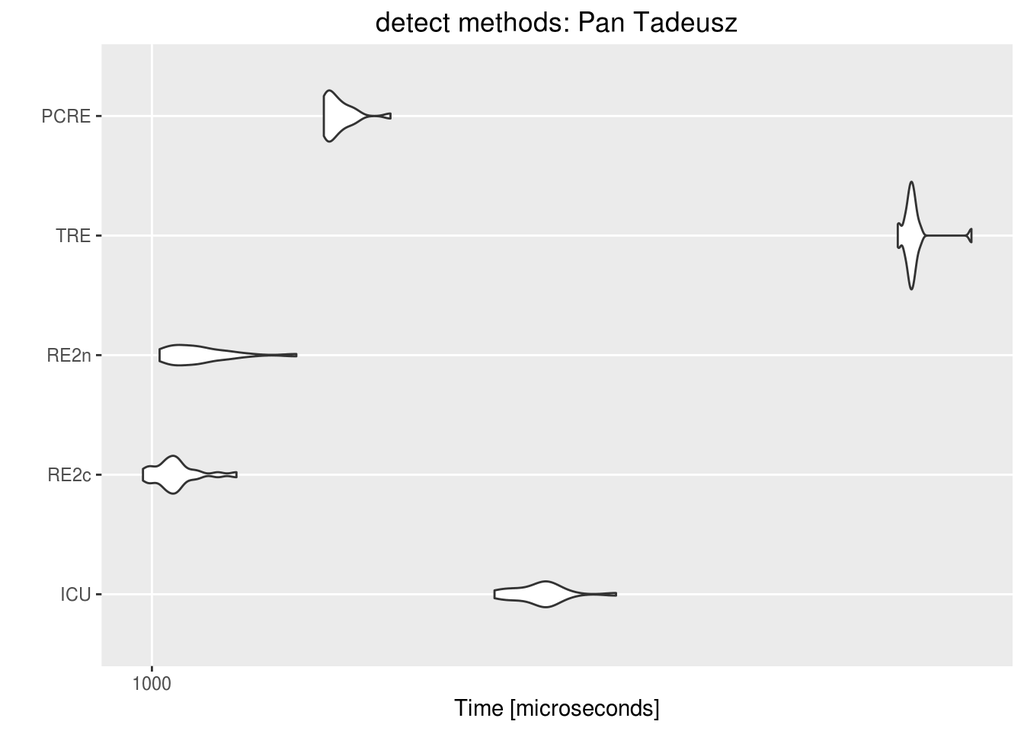

```r
if (!file.exists('./pan_tadeusz_15.txt')) {
    # don't change the URL!
    download.file('https://raw.githubusercontent.com/gagolews/stringi/master/devel/benchmarks/pan_tadeusz_15.txt',
                  './pan_tadeusz_15.txt')
}
pan_tadeusz <- enc2native(readLines('./pan_tadeusz_15.txt', encoding="UTF-8"))
sie <- enc2native(stri_enc_fromutf32(c(115,105,281)))
regexp = re2(sie)
invisible(gc(reset=TRUE))

res = microbenchmark(
    ICU = stri_detect_regex(pan_tadeusz, sie),
    RE2c = re2_detect(pan_tadeusz, regexp),
    RE2n = re2_detect(pan_tadeusz, sie),
    TRE = grepl(sie, pan_tadeusz),
    PCRE = grepl(sie, pan_tadeusz, perl=TRUE),
    times = 20
)
plot(autoplot(res) + ggtitle("detect methods: Pan Tadeusz"))
```

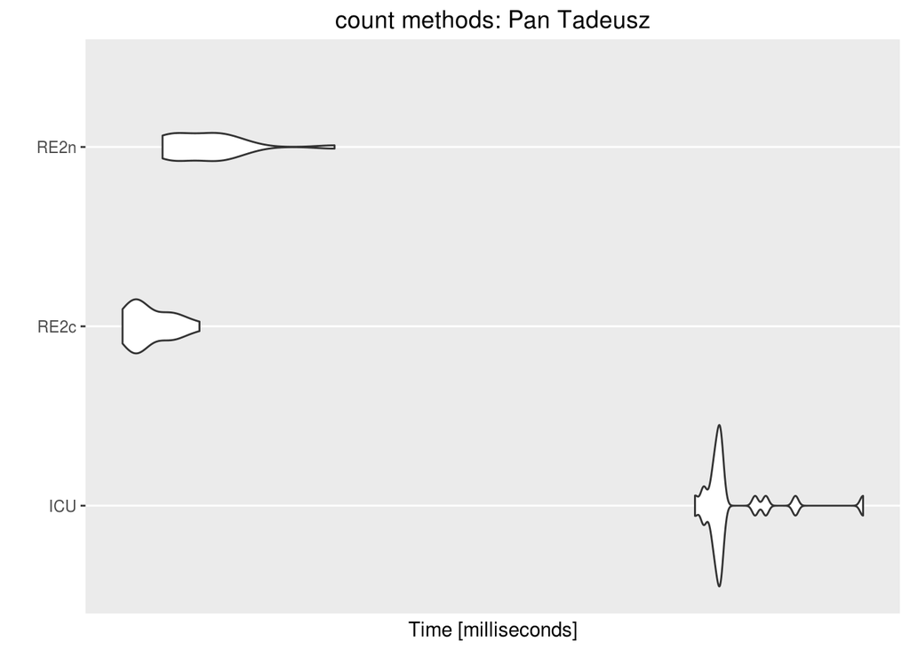

```r
pan_tadeusz <- readLines('./pan_tadeusz_15.txt', encoding="UTF-8")
invisible(gc(reset=TRUE))
autoplot(
    microbenchmark(
        ICU = stri_count_regex(pan_tadeusz, sie),
        RE2c = re2_count(pan_tadeusz, regexp),
        RE2n = re2_count(pan_tadeusz, sie),
        times = 20
    )
) + ggtitle("count methods: Pan Tadeusz")
```

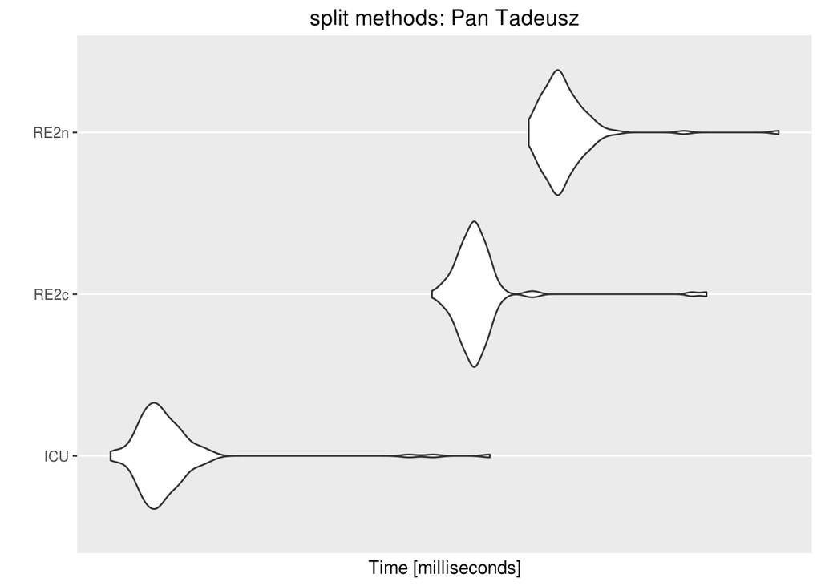

```r
regexp = re2("\\P{L}")
autoplot(microbenchmark(
    ICU = stri_split_regex(pan_tadeusz, "\\P{L}"),
    RE2c = re2_split(pan_tadeusz, regexp),
    RE2n = re2_split(pan_tadeusz, "\\P{L}")
)) + ggtitle("split methods: Pan Tadeusz")
```

### Detect Methods

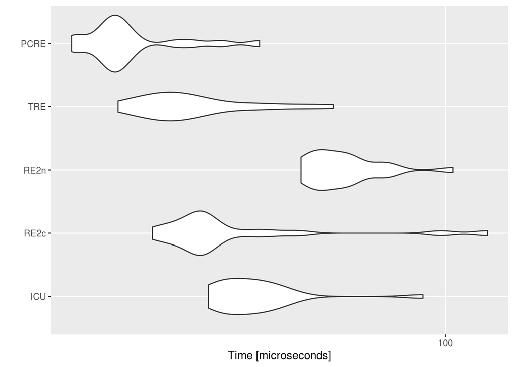

```r
s <- c("Lorem", "ipsum", "dolor", "sit", "amet", "consectetur", "adipisicing",
       "elit", "Proin", "nibh", "augue", "suscipit", "a", "scelerisque",
       "sed", "lacinia", "in", "mi", "Cras", "vel", "lorem", "Etiam",
       "pellentesque", "aliquet", "tellus", "Phasellus", "pharetra",
       "nulla", "ac", "diam", "Quisque", "semper", "justo", "at", "risus",
       "Donec", "venenatis", "turpis", "vel", "hendrerit", "interdum",
       "dui", "ligula", "ultricies", "purus", "sed", "posuere", "libero",
       "dui", "id", "orci", "Nam", "congue", "pede", "vitae", "dapibus",
       "aliquet", "elit", "magna", "vulputate", "arcu", "vel", "tempus",
       "metus", "leo", "non", "est", "Etiam", "sit", "amet", "lectus",
       "quis", "est", "congue", "mollis", "Phasellus", "congue", "lacus",
       "eget", "neque")

srep  <- rep(s, 100)
srep2 <- stri_dup(s, 1000)

pat1 = "^[A-Z]"
pat2 = "[a-z]$"
pat3 = "^[a-z]+$"

run_detect = function(s,pat){
    regexp = re2(pat)
    autoplot(microbenchmark(
    ICU = stri_detect_regex(s,pat1),
    RE2c = re2_detect(s, regexp),
    RE2n = re2_detect(s, pat),
    TRE = grepl(pat, s),
    PCRE = grepl(pat, s, perl = T),
    times = 20
    ))
}

run_detect(s, pat1)
```

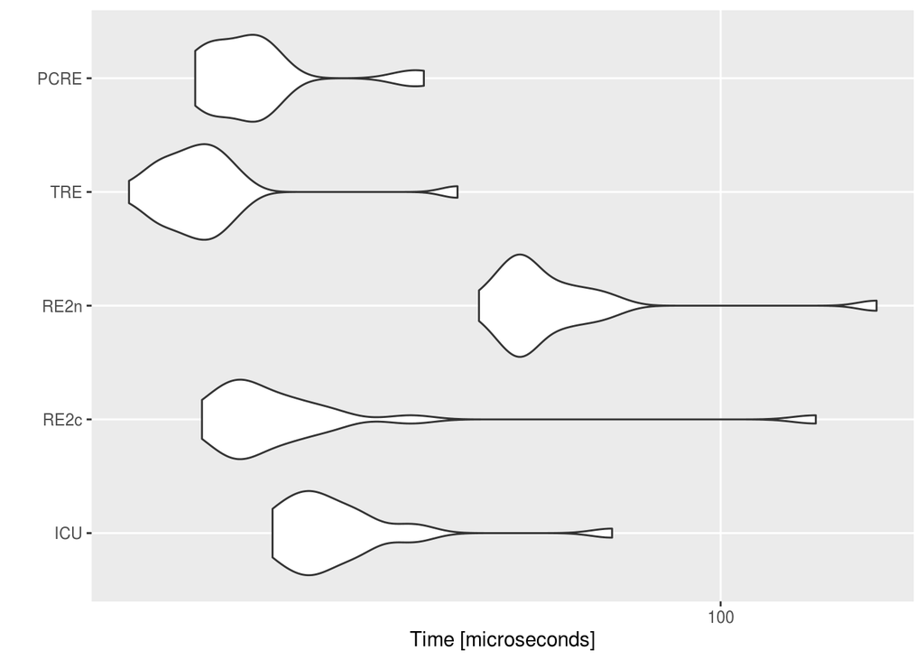

```r
run_detect(s, pat2)
```

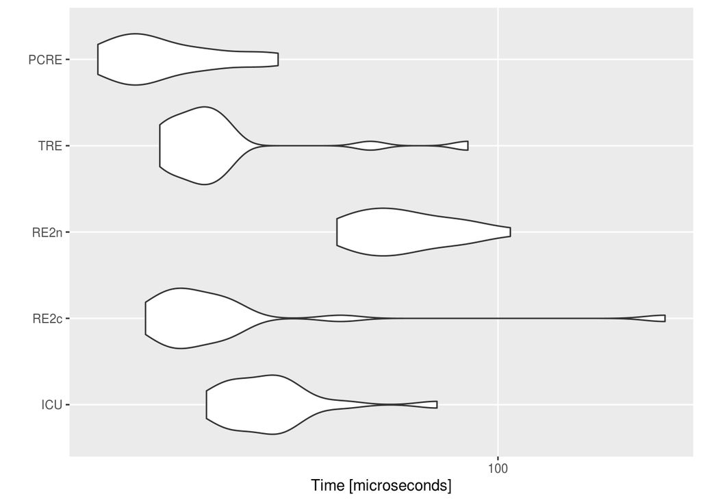

```r
run_detect(s, pat3)
```

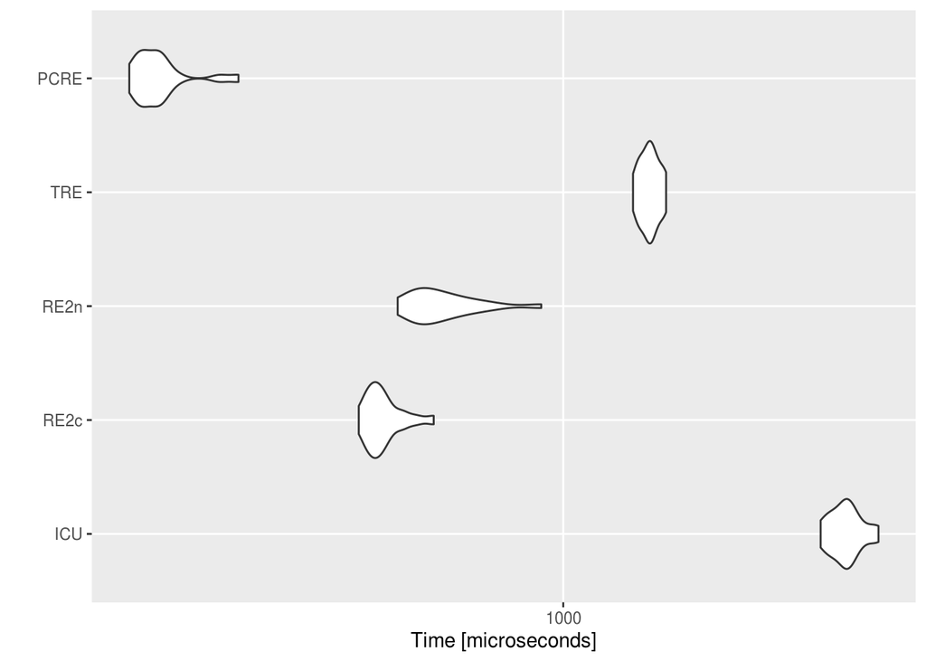

```r
run_detect(srep, pat1)
```

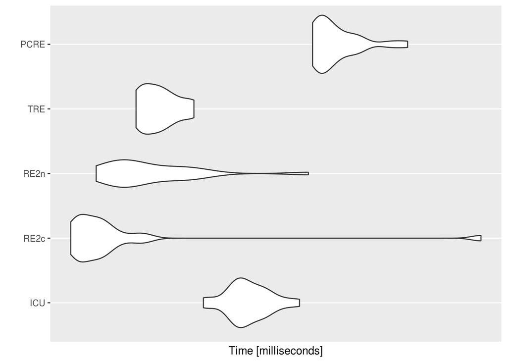

```r
run_detect(srep, pat2)
```

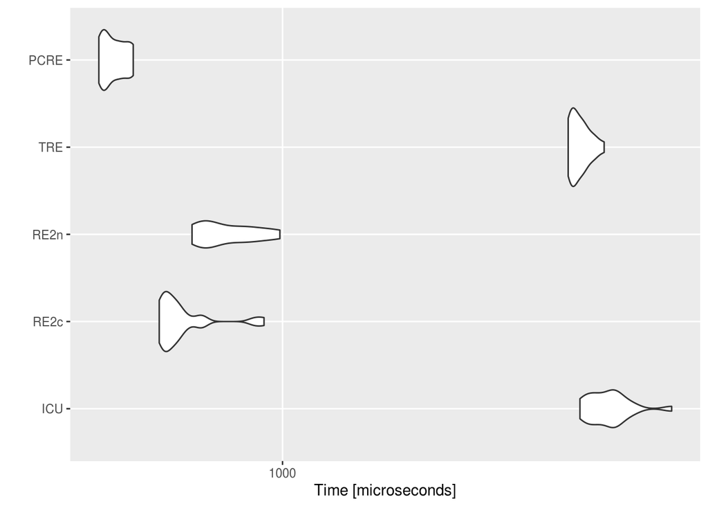

```r
run_detect(srep, pat3)
```

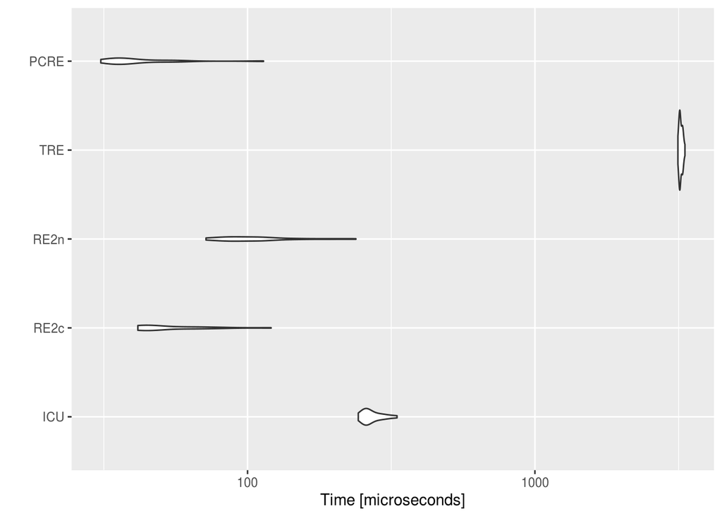

```r
run_detect(srep2, pat1)
```

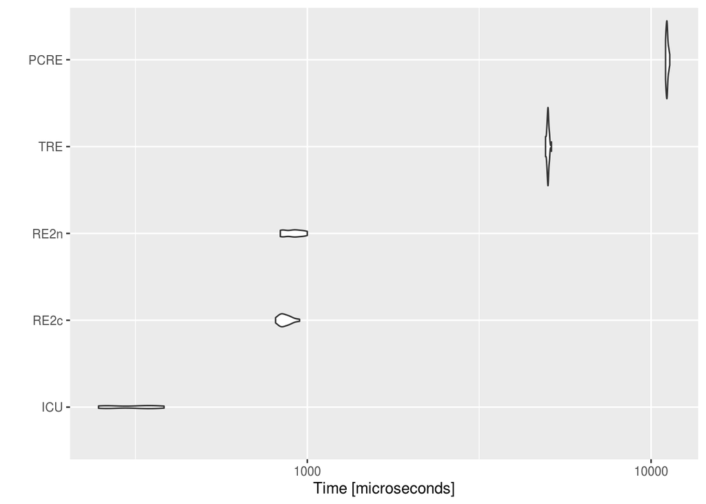

```r
run_detect(srep2, pat2)
```

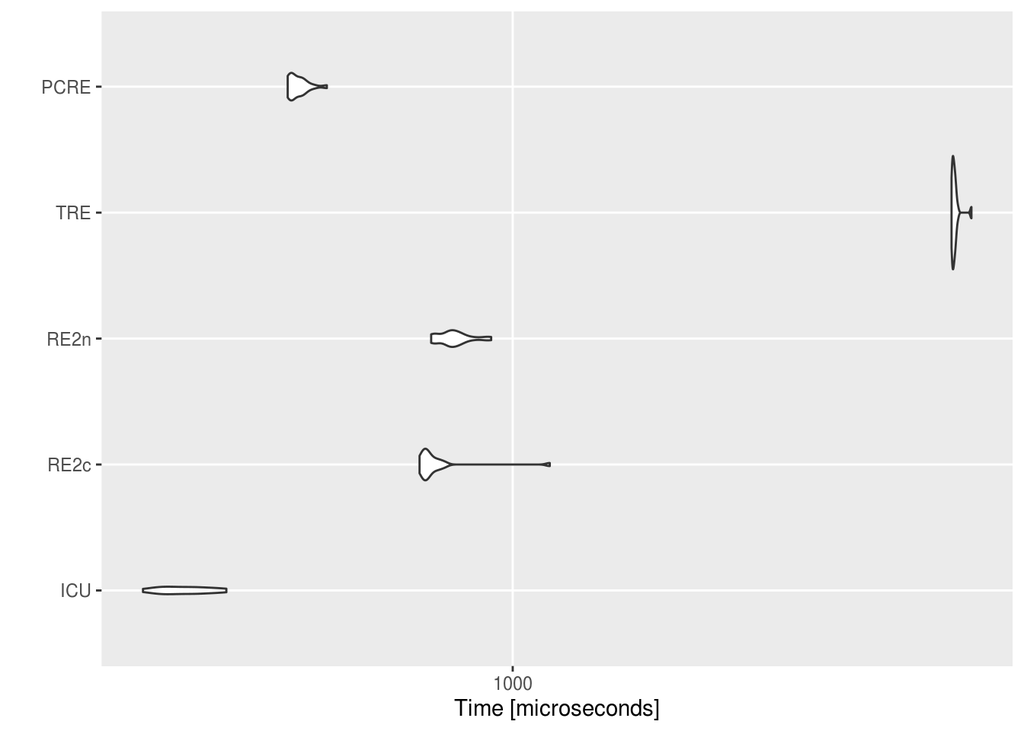

```r
run_detect(srep2, pat3)
```

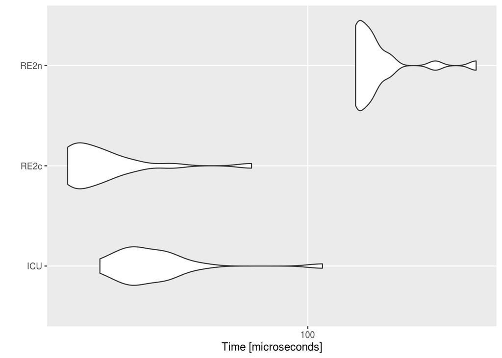

```r
p <- c("^[A-Z]", ".{3}", ".{4}", "[^a]+")
srep2 <- rep(s, 10)
prep <- rep(p, 60)

run_detect = function(s,pat){
    regexp = re2(pat)
    autoplot(microbenchmark(
    ICU = stri_detect_regex(s,pat1),
    RE2c = re2_detect(s, regexp),
    RE2n = re2_detect(s, pat),
    times = 20
    ))
}

run_detect(s, p)
```

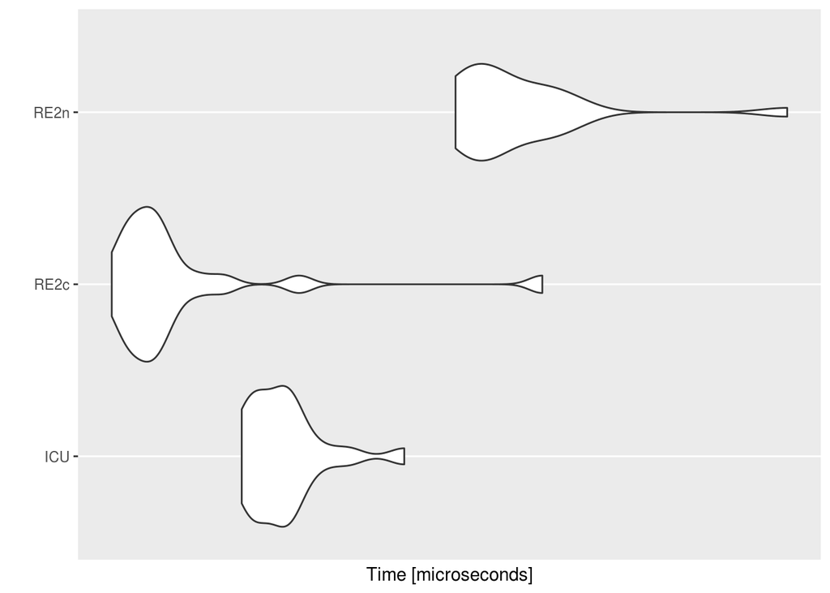

```r
run_detect(srep2, p)
```

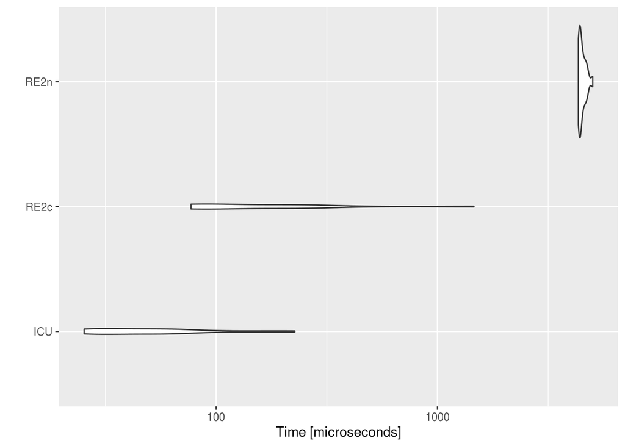

```r
run_detect(s, prep)
```

Regex lookup for words with at least 3 consecutive digits [Latin&Polish letters, digits]

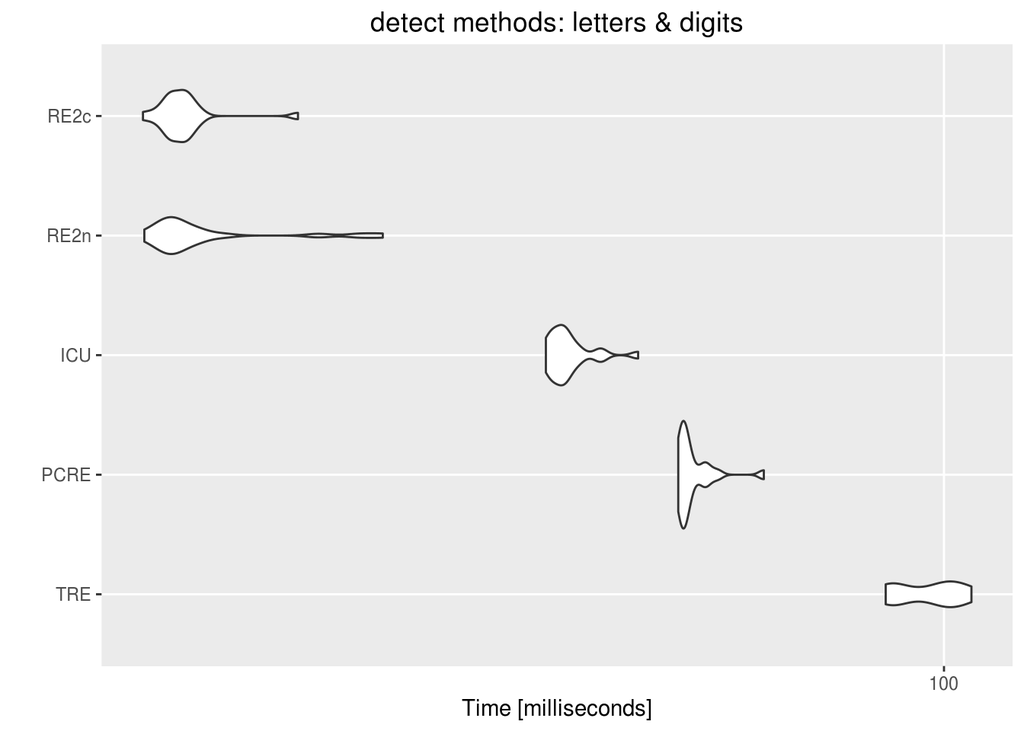

```r
lettersdigits <- c(0:9, stri_enc_fromutf32(list(97L, 98L, 99L, 100L, 101L, 102L, 103L,
                                                104L, 105L, 106L, 107L,  108L, 109L, 110L, 111L, 112L, 113L, 114L, 115L,
                                                116L, 117L, 118L,  119L, 120L, 121L, 122L, 261L, 263L, 281L, 322L, 324L,
                                                243L, 347L,  378L, 380L)))
lettersdigits <- enc2native(lettersdigits)

set.seed(123)
letdig <- replicate(100000, {
    paste(sample(lettersdigits,
                 floor(abs(rcauchy(1, 10))+1), replace=TRUE), collapse='')
})

regexp = re2("[0-9]{3,}")
invisible(gc(reset=TRUE))
res = microbenchmark(
    TRE = grepl("[0-9]{3,}", letdig),
    PCRE = grepl("[0-9]{3,}", letdig, perl=TRUE),
    ICU = stri_detect_regex(letdig, "[0-9]{3,}"),
    RE2n = re2_detect(letdig, "[0-9]{3,}"),
    RE2c = re2_detect(letdig, regexp),
    times = 20
)
autoplot(res) + ggtitle("detect methods: letters & digits")
```

### Long String

Finds a word at the beginning of a long string (Latin&Polish letters).

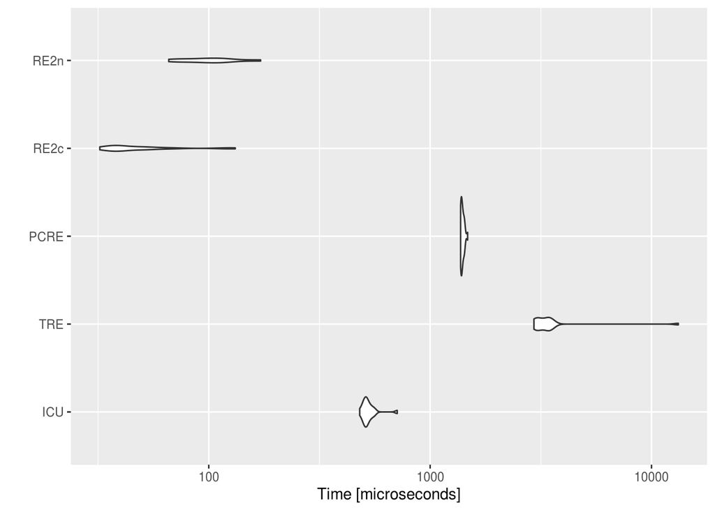

```r
str <- enc2native(stri_join(stri_dup("kaw\u0105", 100000), "law\u0105"))
firstword <- enc2native("kaw\u0105")

invisible(gc(reset=TRUE))
regexp = re2(firstword)
autoplot(microbenchmark(
    ICU = stri_detect_regex(str, firstword),
    TRE = grepl(firstword, str),
    PCRE = grepl(firstword, str, perl=TRUE),
    RE2c = re2_detect(str, regexp),
    RE2n = re2_detect(str, firstword)
, times = 20))
```

Finds a word at the end of a long string (Latin&Polish letters).

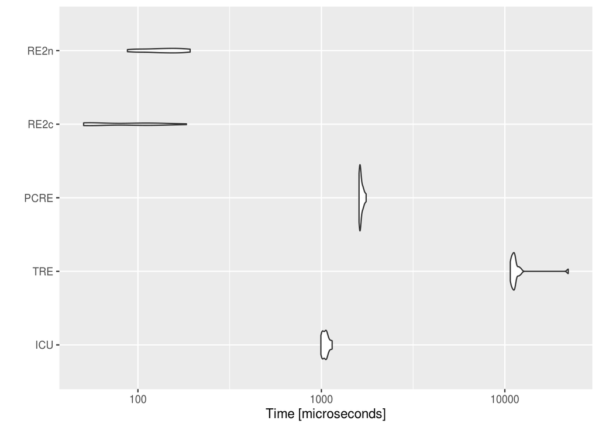

```r
str <- enc2native(stri_join(stri_dup("kaw\u0105", 100000), "law\u0105"))
lastword <- enc2native("law\u0105")
invisible(gc(reset=TRUE))
regexp = re2(lastword)
autoplot(microbenchmark(
    ICU = stri_detect_regex(str, lastword),
    TRE = grepl(lastword, str),
    PCRE = grepl(lastword, str, perl=TRUE),
    RE2c = re2_detect(str, regexp),
    RE2n = re2_detect(str, lastword),
    times = 20
))
```

Does not find a long overlapping pattern in a string (Latin&Polish letters)

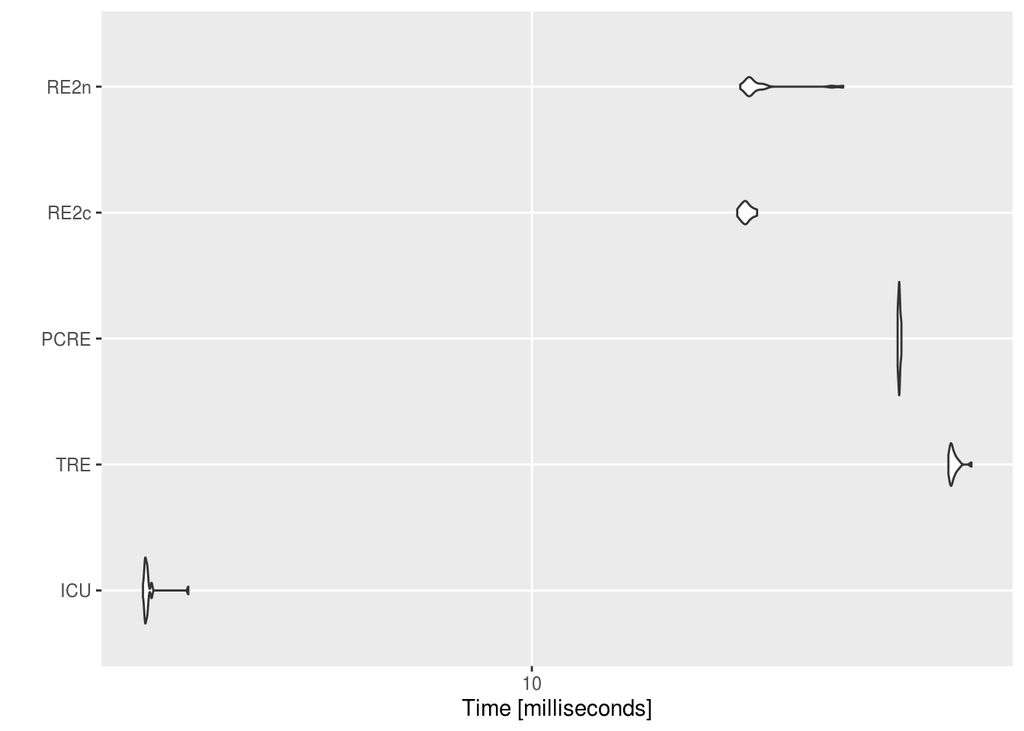

```r
str <- enc2utf8(stri_dup("ab\u0105", 4000))
lastword <- enc2utf8(stri_join(stri_dup("ab\u0105", 400), "c"))
invisible(gc(reset=TRUE))
regexp = re2(lastword)
autoplot(microbenchmark(
    ICU = stri_detect_regex(str, lastword),
    TRE = grepl(lastword, str),
    PCRE = grepl(lastword, str, perl=TRUE),
    RE2c = re2_detect(str, regexp),
    RE2n = re2_detect(str, lastword),
    times = 20
))
```